# Lab 1 - Parte 2

### Apresentação dos dados

Este documento faz uma análise descritiva e responde algumas perguntas sobre dados referentes a disciplinas da Universidade Federal de Campina Grande (UFCG). Em nosso data frame os dados correspondem aos períodos 2002.1 - 2014.1 em que cada linha representa uma disciplina cursada por um aluno. As principais variáveis que podemos destacar são:

- *Matricula*: Não a original, mas capaz de identificar cada aluno diferente
- *Cod_Curso*: Código para identificar cursos diferentes. Cursos com o mesmo nome, mas em campi diferentes são considerados distintos.
- *Nome_Curso*: Nome do curso.
- *Cod_Disciplina*: Código para identificar cada disciplina.
- *Nome_Disciplina*: Nome da disciplina
- *Periodo*: Período no qual a disciplina foi cursada.
- *Media_Disciplina*: Média atinginda pelo aluno ao final do período.
- *Campus*: Campus ao qual o curso pertence.

São listados 95 cursos com códigos diferentes. Abaixo há mais detalhes sobre os dados no geral.

```r
cursos = read.csv("../../alunosUFCGAnon.csv")

length(unique(cursos$Cod_Curso))
```

```
## [1] 95
```

```r
summary(cursos)
```

```
##    Matricula        Cod_Curso        Cod_Disciplina      Cod_Evasao
##  B32258 :   143   Min.   :11104120   Min.   :1105013   Min.   :0.00000
##  B30701 :   138   1st Qu.:13306200   1st Qu.:1301063   1st Qu.:0.00000
##  B22035 :   132   Median :21204100   Median :2101046   Median :0.00000
##  B25585 :   129   Mean   :28575038   Mean   :2815884   Mean   :0.06797
##  B27775 :   128   3rd Qu.:41403100   3rd Qu.:4101151   3rd Qu.:0.00000
##  B28061 :   124   Max.   :91402100   Max.   :9101274   Max.   :1.00000
##  (Other):919735
##                      Nome_Curso        Periodo
##  MEDICINA VETERINÁRIA - D : 60372   Min.   :2002
##  MEDICINA - D             : 56689   1st Qu.:2008
##  ENFERMAGEM - D           : 53611   Median :2011
##  ENGENHARIA CIVIL - D     : 42458   Mean   :2010
##  ENGENHARIA ELÉTRICA      : 41408   3rd Qu.:2012
##  CIÊNCIA DA COMPUTAÇÃO - D: 38246   Max.   :2014
##  (Other)                  :627745
##                                Nome_Disciplina      Creditos
##  CALCULO DIFERENCIAL E INTEGRAL I      : 14822   Min.   : 0.00
##  ÁLGEBRA VETORIAL E GEOMETRIA ANALÍTICA: 13091   1st Qu.: 4.00
##  FÍSICA GERAL I                        :  7620   Median : 4.00
##  CALCULO DIFERENCIAL E INTEGRAL II     :  7285   Mean   : 3.89
##  METODOLOGIA CIENTÍFICA                :  7068   3rd Qu.: 4.00
##  LINGUA PORTUGUESA                     :  6581   Max.   :53.00
##  (Other)                               :864062
##                                             Departamento
##  UNID. ACAD. DE EDUCAÇÃO                          : 89211
##  UNID. ACAD. DE DIREITO                           : 73924
##  UNID. ACAD. DE MEDICINA VETERINÁRIA              : 60320
##  UNID. ACAD. DE MATEMÁTICA                        : 55618
##  UNID. ACAD. DE AGRONOMIA E TECNOLOGIA DE ALIMENTO: 38988
##  UNID. ACAD. DE SISTEMAS E COMPUTAÇÃO             : 36013
##  (Other)                                          :566455
##  Media_Disciplina                Situacao          Centro
##  Min.   : 0.000   Aprovado           :751010   Min.   :11.00
##  1st Qu.: 6.000   Reprovado          : 74289   1st Qu.:13.00
##  Median : 7.600   Reprovado por Falta: 69216   Median :21.00
##  Mean   : 6.789   Trancado           : 26014   Mean   :28.34
##  3rd Qu.: 8.500                                3rd Qu.:41.00
##  Max.   :10.000                                Max.   :91.00
##  NA's   :26042
##      Campus      Creditos_Curso           Tipo        Periodo_Ingresso
##  Min.   :1.000   Min.   :120.0   Obrigatória:828078   Min.   :1995
##  1st Qu.:1.000   1st Qu.:204.0   Optativa   : 92451   1st Qu.:2007
##  Median :2.000   Median :240.0                        Median :2009
##  Mean   :2.641   Mean   :246.6                        Mean   :2009
##  3rd Qu.:4.000   3rd Qu.:265.0                        3rd Qu.:2011
##  Max.   :9.000   Max.   :526.0                        Max.   :2014
##                  NA's   :3332
##  Periodo_Relativo
##  Min.   : 1.000
##  1st Qu.: 2.000
##  Median : 4.000
##  Mean   : 4.231
##  3rd Qu.: 6.000
##  Max.   :28.000
##
```

### Em quais cursos estão as melhores e piores notas? Por que você acha que isso acontece em cada caso?

Existem duas maneiras principais e diretas de avaliar quais são os cursos com melhores e piores notas, pelo cáclculo de média ou mediana. Devido a quantidade muito variada de alunos em cada curso, escolhemos responder esta pergunta utilizando a mediana, dessa forma o valor não será afetado por outliers.

Para cada curso, foi calculada a mediana sobre todas as médias de disciplinas dos alunos, desconsiderando valores vazios. Abaixo temos dois gráficos que, de maneira ordenada, exibe os dez melhores e piores cursos com relação a médias em disciplinas.

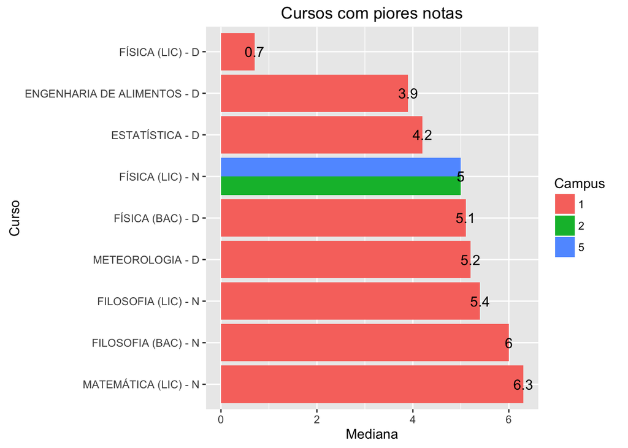

```r
cursos = cursos[!is.na(cursos$Media_Disciplina),]
cursos_mediana = aggregate(cursos$Media_Disciplina, list(cursos$Cod_Curso, cursos$Nome_Curso, cursos$Campus), FUN = median)

cursos_mediana = cursos_mediana[ order( cursos_mediana$x),]

ggplot(cursos_mediana[1:10,], aes( y = x, x = reorder(Group.2, -x), fill=factor(Group.3))) + geom_bar(position="dodge", stat="identity") +  geom_text(aes(label=x),size = 4) + coord_flip() + labs(title = "Cursos com piores notas", x = "Curso", y = "Mediana", fill = "Campus")
```

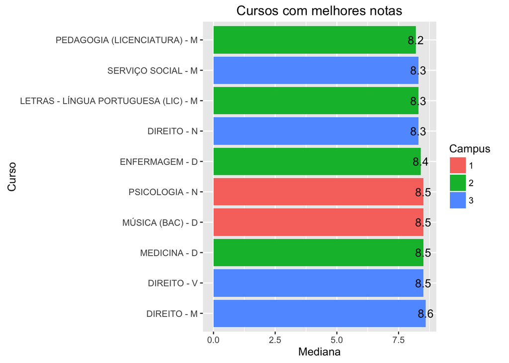

```r
ggplot(cursos_mediana[86:95,], aes( y = x, x = reorder(Group.2, -x),, fill=factor(Group.3))) + geom_bar(stat="identity", position="dodge") +  geom_text(aes(label=x),size = 4) + coord_flip()  + labs(title = "Cursos com melhores notas", x = "Curso", y = "Mediana", fill = "Campus")
```

Segundo os gráficos acima, podemos concluir que, com mediana igual a 0.7, o curso **FÍSICA (LIC) - D** é considerado aquele com piores notas, enquanto **DIREITO - M**, com mediana igual a 8.6, é considerado aquele com melhores notas. O curso de Física pertence ao campus **1** e o de direito ao campus **3**.

```r
unique(cursos[cursos$Cod_Curso == cursos_mediana[1,]$Group.1,]$Campus)
```

```
## [1] 1
```

```r
unique(cursos[cursos$Cod_Curso == cursos_mediana[95,]$Group.1,]$Campus)
```

```
## [1] 3
```

Esse resultado pode ser afetado de diversas maneiras. Nos dados utilizados para essa análise, para o curso de direto temos mais de 23000 valores enquando física não chega a 700. Em casos desse tipo a quantidade de desistentes ou reprovações tem um efeito maior no grupo de menor valor. Além do mais, podemos ver no boxplot abaixo que para o curso de direito as notas estão bem concentradas em altos valores e apesar de apresentar outliers, estes não exercem influência. Por outro lado, as notas do curso de física têm uma maior variabilidade e concentração de baixos valores valores.

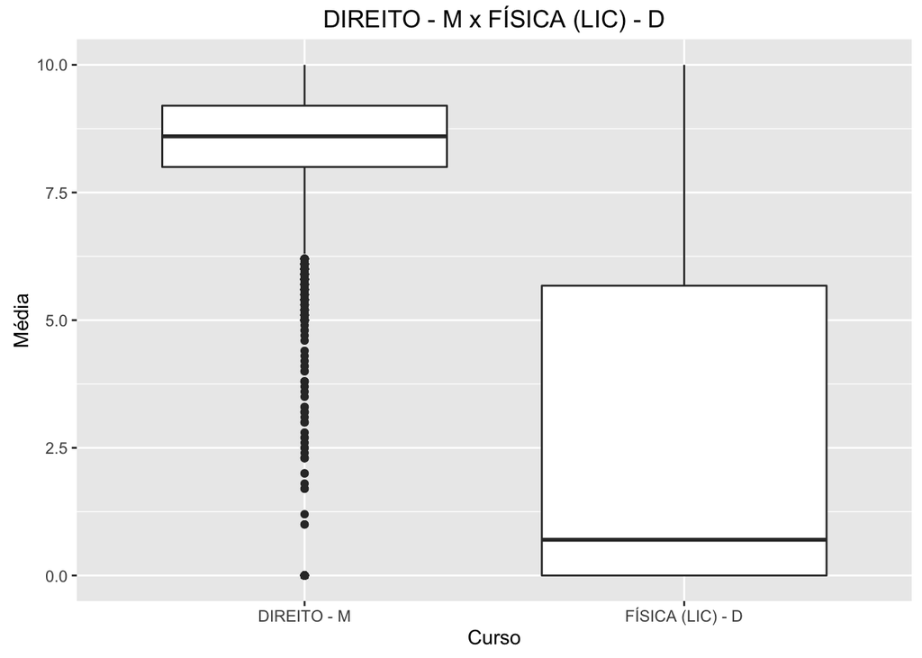

```r
ggplot(cursos[cursos$Cod_Curso == 11105110 | cursos$Cod_Curso == 31350100,], aes( y = Media_Disciplina, x = Nome_Curso)) + geom_boxplot() + labs(title = "DIREITO - M x FÍSICA (LIC) - D", x = "Curso", y = "Média")
```

### Em qual período estão as melhores e piores notas do curso de Ciência da Computação?

Seguindo o mesmo procedimento adotado na questão anterior, agora agrupamos as médias por período. Porém, no gráfico abaixo é possível identificar um problema na definição de melhor e pior período. Ao verificar a mediana dos últimos períodos, vemos que todos pussuem o mesmo valor e variabilidade semelhante, impossibilitando escolher apenas um.

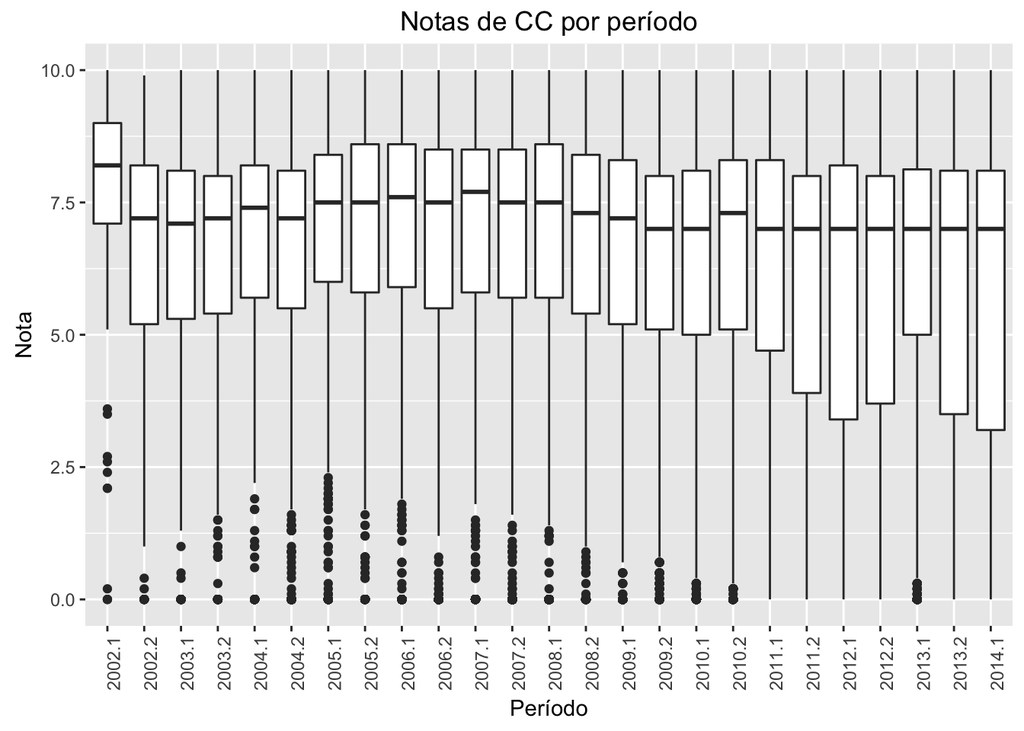

```r
ccc_medias = subset(cursos, Cod_Curso == 14102100)

ggplot(ccc_medias, aes(factor(Periodo), Media_Disciplina )) + geom_boxplot() + labs(title = "Notas de CC por período", x = "Período", y = "Nota") + theme(axis.text.x = element_text(angle = 90, hjust = 1))
```

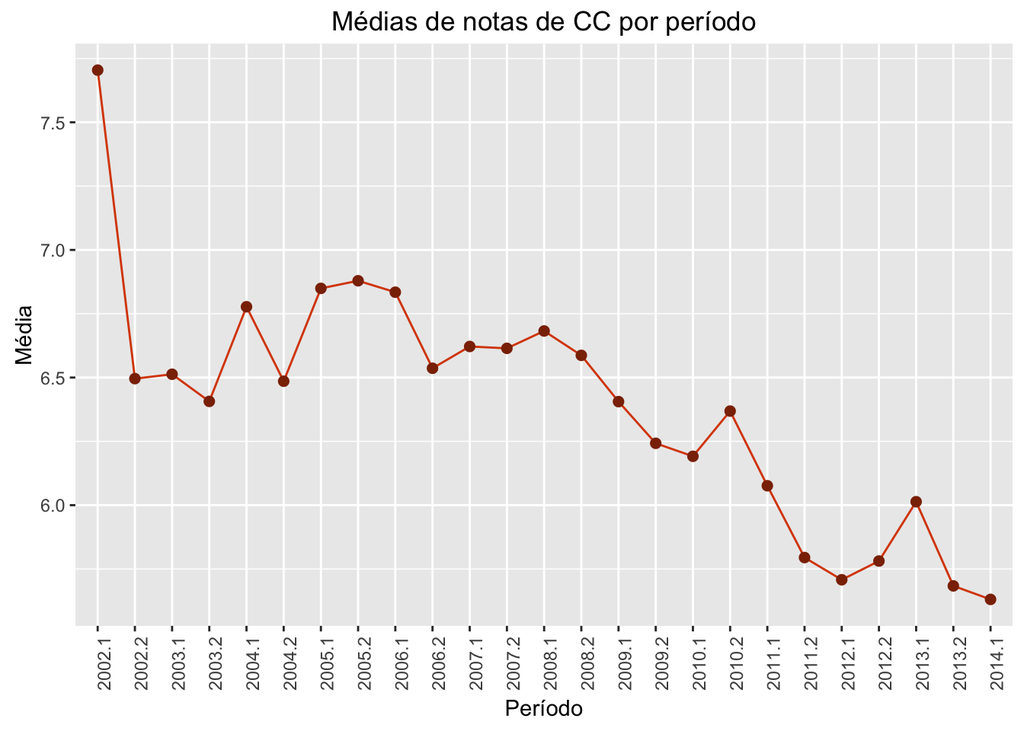

```r
ccc_medias = aggregate(ccc_medias$Media_Disciplina, list(ccc_medias$Periodo), FUN = mean, na.rm=TRUE)

ggplot(ccc_medias, aes( y = x, x =factor( Group.1), group = 1)) + geom_line(color = "#d94801") + geom_point(size = 2, color = "#8c2d04") + labs(title = "Médias de notas de CC por período", x = "Período", y = "Média") + theme(axis.text.x = element_text(angle = 90, hjust = 1))
```

### Existe correlação entre as notas de Matemática Discreta e Cálculo I para o curso de Ciência da Computação? Se sim, a correlação é positiva ou negativa? Qual a força dessa correlação?

Para esta análise serão considerados apenas as notas de pessoas que cursaram as disciplinas Matemática Discreta e Cálculo I, em outras palavras, apenas quando houver notas disponíveis referentes as duas disciplinas ligeada a uma só matrícula. Para casos de quando há mais de uma nota para as disciplinas, apenas a maior é considerada.

Após realizado o filtro e recortes adequados, plotamos abaixo um gráfico em que as notas de Cálculo I estão representadas no eixo X e as notas de Matemática Discretas estão representadas no eixo Y. Observamos que há um tipo de marcação na imagem gerada, exatamente onde as notas atingem o valor 5. Os pontos anteriores a estar marcação estão bem dispersos, enquanto os após a marcação se encontram mais concentrados em na região direita superior.

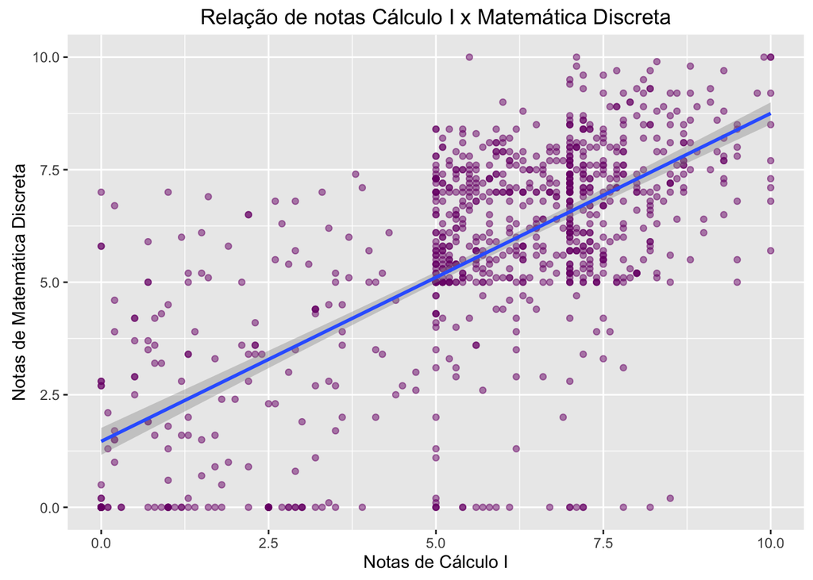

```r
discreta = subset(cursos, Cod_Disciplina == 1109113) %>% group_by(Matricula) %>% top_n(1, Media_Disciplina)
calculo = subset(cursos, Cod_Disciplina == 1109103) %>% group_by(Matricula) %>% top_n(1, Media_Disciplina)

disc = subset(discreta, select = c("Matricula", "Media_Disciplina"))
calc = subset(calculo, select = c("Matricula", "Media_Disciplina"))

disc.calc = merge(calc,disc, by.x = "Matricula", by.y = "Matricula")

ggplot(disc.calc, aes(Media_Disciplina.x, Media_Disciplina.y)) + geom_point(alpha = 0.5, color = "#7a0177") + labs(title = "Relação de notas Cálculo I x Matemática Discreta", x = "Notas de Cálculo I", y = "Notas de Matemática Discreta") + geom_smooth(method = lm)
```

Apesar de um pouco disperso, no gráfico acima os pontos se desenham de maneira em é possível observar uma tendência. Desconsiderando outliers, vemos que a dendência é de que as notas de ambas as disciplinas geralmente crescem juntas. Esse é um indicativo de que há correlação entre as duas variáveis. Abaixo temos o valor da correlação calculado:

```r
cor(disc.calc$Media_Disciplina.x, disc.calc$Media_Disciplina.y)
```

```
## [1] 0.6927944
```

Seu valor é igual a 0.6927944 e por ser diferente de zero podemos afirmar que há correlação. Um valor acima de 0 significa que essa correlação é possitiva. Quanto mais próximo de 1 ou -1, maior a força. Sendo nosso valor quase 0.70, podemos considerar que há uma forte correlação positiva.